# Vectors

# 1 Vectors

## 1.1 Introduction

### 1.1.1 Prerequisites（準備）

準備としてパッケージのインストール：

```r
library(tidyverse)
library(tibble)
```

## 1.2 Vector basics（ベクトルの基本）

**ベクトルの種類**

- Atomic vectors: logical, integer, double, character, complex, raw
- Integer and double vectors: numeric vectors
- Lists (recursive vectors): 他のリストを中に含むことができる．色んな種類のデータを含められる（heterogeneous）．
- `NULL`: ベクトルがないことを示す．長さ0のベクトル．
- `NA`: ベクトル中の値がないことを示す．

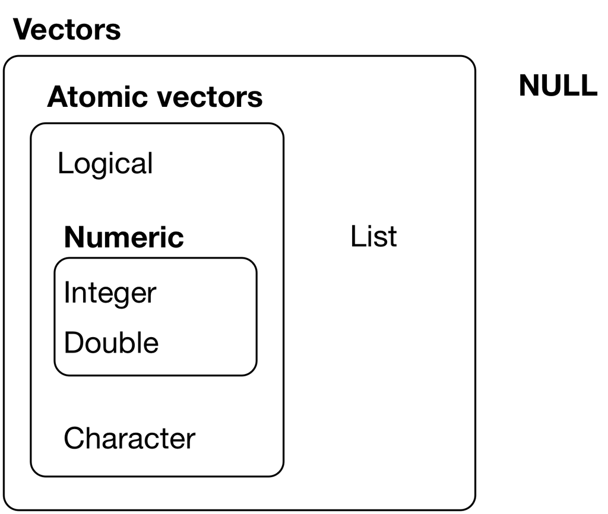

* **Rにおけるベクトルの種類の階層**

**ベクトルの持つ性質**

- 型：`typeof()`で確認できる：

```r
    typeof(letters)
```

```
## [1] "character"
```

```r
    typeof(1:10)
```

```
## [1] "integer"
```

- 長さ：`length()`で確認できる：

```r
    x <- list("a", "b", 1:10)
    length(x)
```

```
## [1] 3
```

## 1.3 Important types of atomic vector（atmic vectorの重要な型）

4つの重要な型：

- logical（論理型）
- integer（整数型）
- double（倍精度浮動小数点型）
- character（文字型）

### 1.3.1 Logical（論理型）

- とり得る値: `FALSE`, `TRUE`, `NA`
- 比較の演算子を用いた結果として現れることが多い：

```r
1:10 %% 3 == 0
```

```
##  [1] FALSE FALSE  TRUE FALSE FALSE  TRUE FALSE FALSE  TRUE FALSE
```

```r
c(TRUE, TRUE, FALSE, NA)
```

```
## [1]  TRUE  TRUE FALSE    NA
```

### 1.3.2 Numeric（数値型）

- Integer：整数型
- double： 倍精度浮動小数点型（数値データのRにおけるデフォルト）  
  数値の後に「L」をつけると整数型になる：

```r
typeof(1)
```

```
## [1] "double"
```

```r
typeof(1L)
```

```
## [1] "integer"
```

```r
1.5L
```

```
## [1] 1.5
```

**integerとdoubleの違い**

- doubleの値は近似値である：浮動小数点表記の限界のため、常に誤差を伴う。

```r
    x <- sqrt(2) ^ 2
    x
```

```
## [1] 2
```

```r
    x - 2
```

```
## [1] 4.440892e-16
```

数値比較の際、`==`ではなく`dplyr::near()`を用いるとよい（誤差を考慮して比較）。

- Integerにおける特殊な値：`NA`
- doubleにおける特殊な値：`NA`, `NaN`, `Inf`, `-Inf`

```r
    c(-1, 0, 1) / 0
```

```
## [1] -Inf  NaN  Inf
```

これらの値のチェックには`is.finite()`, `is.infinite()`, `is.nan()`を用いる（`==`ではない）。

| Function | 0 | Inf | NA | NaN |
| --- | --- | --- | --- | --- |
| is.finite() | X |  |  |  |
| is.infinite() |  | X |  |  |
| is.na() |  |  | X | X |
| is.nan() |  |  |  | X |

### 1.3.3 Character（文字型）

Character（文字型）ベクトルは複雑な型である。なぜなら、characterベクトルのそれぞれの要素はstring（文字列）であり、stringは任意の量のデータを含むからである。

Rではユニークな文字列は一度だけメモリに保存され、以降同じ文字列を使用する際はポインタで示される。このことによりメモリの使用量が軽減されている（文字列の使用メモリ量は`pryr::object_size()`で確認できる）。  
以下の例でその挙動を見てみよう：

```r
x <- "This is a reasonably long string."
pryr::object_size(x)
```

```
## 136 B
```

```r
y <- rep(x, 1000) # xに入れた文字列を1000回繰り返す
pryr::object_size(y)
```

```
## 8.13 kB
```

yの使用メモリ量はxの1000倍もない。これはyの各要素が同じ文字列なので、ポインタで示される ためである。ポインタは8バイトなので、1000個のポインタと136バイトの文字列を合わせて8 * 1000 + 136 = 8.13 kBとなる。

### 1.3.4 Missing values（欠損値）

Atomic vectorの各型にはそれぞれの欠損値がある：

```r
NA            # logical
```

```
## [1] NA
```

```r
NA_integer_   # integer
```

```
## [1] NA
```

```r
NA_real_      # double
```

```
## [1] NA
```

```r
NA_character_ # character
```

```
## [1] NA
```

普段の使用では自動的に適切な型に変換されるため、これらを意識する必要はない。しかしいくつかの関数においては厳密な取り扱いが必要になることがあるため、これらの知識が必要となってくる。

## 1.4 Using atomic vectors（atomic vectorの使用）

### 1.4.1 Coercion（強制、無理強い）

- 明示的な変換：`as.logical()` `as.integer()` `as.double()` `as.character()`などを使用した変換
- 暗黙の変換：  
  logical（論理型）ベクトルに対して数値を引数とする関数を適用する場合、  
  doubleベクトルに対して整数（integer）を引数とする関数を適用する場合、など。
- logical（論理型）ベクトルに対して数値を引数とする関数を適用する例。  
  `TRUE`=1, `FALSE`=0と変換される：

```r
x <- sample(20, 100, replace = TRUE)
y <- x > 10
sum(y)  # how many are greater than 10?
```

```
## [1] 52
```

```r
mean(y) # what proportion are greater than 10?
```

```
## [1] 0.52
```

- integer（整数型）がlogical（論理型）に変換される例。  
  0=`FALSE`, 0以外=`TRUE`と変換される：

```r
if (length(x)) {
  # do something
}
```

コードが見難くなるのでお勧めできない。この場合は`length(x) > 0`とする方がよい。

- `c()`で作成したベクトルの中に複数の型の値が入っている場合：

```r
typeof(c(TRUE, 1L))
```

```
## [1] "integer"
```

```r
typeof(c(1L, 1.5))
```

```
## [1] "double"
```

```r
typeof(c(1.5, "a"))
```

```
## [1] "character"
```

atomic vector の各要素に異なる型の値を持たせることはできない。  
異なる型のデータを持たせる場合はlistを使う。

### 1.4.2 Test functions（テストのための関数）

ベクトルの型の確認：

- `typeof()`を使って確認する。
- test function（戻り値は`TRUE`または`FALSE`）を使って確認する。  
  test functionの一覧表：

| Function | lgl | int | dbl | chr | list |
| --- | --- | --- | --- | --- | --- |
| is_logical() | x |  |  |  |  |
| is_integer() |  | x |  |  |  |
| is_double() |  |  | x |  |  |
| is_numeric() |  | x | x |  |  |
| is_character() |  |  |  | x |  |
| is_atomic() | x | x | x | x |  |
| is_list() |  |  |  |  | x |
| is_vector() | x | x | x | x | x |

### 1.4.3 Scalars and recycling rules（スカラーと再利用ルール）

ベクトルの長さに関するルール。  
長さの異なるベクトル間の演算においては、短い方のベクトルにおいて要素の再利用が行われ、ベクトルの長さを合わせてから演算が実行される。  
ベクトルと「スカラー」（Rでは長さ1のベクトル）を混ぜるときに有用。

```r
sample(10) + 100 # スカラーである100が長さ10のベクトルに変換される。
```

```
##  [1] 101 107 110 108 102 103 106 109 104 105
```

```r
runif(10) > 0.5 # スカラーである0.5が長さ10のベクトルに変換される。
```

```
##  [1] FALSE  TRUE  TRUE FALSE  TRUE  TRUE  TRUE FALSE  TRUE  TRUE
```

長さの異なるベクトルを足した場合の挙動：

```r
1:10 + 1:2
```

```
##  [1]  2  4  4  6  6  8  8 10 10 12
```

短い方のベクトルの長さが、長い方の長さの約数になっていない場合にはwarningが出る。

```r
1:10 + 1:3
```

```
##  [1]  2  4  6  5  7  9  8 10 12 11
```

`tidyverse`における関数では、スカラー以外のベクトルを再利用させるような数式についてはエラーを返すようにできている（意図しない演算が行われることを防ぐため）。もし`tidyverse`の関数において再利用したい場合は`rep()`を使って繰り返してから演算する必要がある:

```r
# tibble(x = 1:4, y = 1:2) # ERROR

tibble(x = 1:4, y = rep(1:2, 2))
```

```
## # A tibble: 4 x 2
##       x     y
##   <int> <int>
## 1     1     1
## 2     2     2
## 3     3     1
## 4     4     2
```

```r
tibble(x = 1:4, y = rep(1:2, each = 2))
```

```
## # A tibble: 4 x 2
##       x     y
##   <int> <int>
## 1     1     1
## 2     2     1
## 3     3     2
## 4     4     2
```

### 1.4.4 Naming vectors（ベクトルの要素に対する命名）

ベクトルの要素に名前をつけられる。  
* `c()`において要素に名前をつける例：

```r
c(x = 1, y = 2, z = 4)
```

```
## x y z
## 1 2 4
```

- `purrr::set_names()`で名前をつける例:

```r
set_names(1:3, c("a", "b", "c"))
```

```
## a b c
## 1 2 3
```

### 1.4.5 Subsetting（サブセットの作成）

`dplyr::filter()`： tibbleにおける行のフィルタリングに使用する。  
* ベクトルにおいては、`x[]`の`[]`の中で要素の番号を指定する：

```r
x <- c("one", "two", "three", "four", "five")
x[c(3, 2, 5)]
```

```
## [1] "three" "two"   "five"
```

```r
x[c(1, 1, 5, 5, 5, 2)]
```

```
## [1] "one"  "one"  "five" "five" "five" "two"
```

```r
x[c(-1, -3, -5)] # 負の値はその部分を除くことを意味する。
```

```
## [1] "two"  "four"
```

```r
# x[c(-3, 4)] # 正負の値が混在するとエラーとなる。
```

```r
x[0] # 0の場合はどの値も含まない。
```

```
## character(0)
```

- 論理型ベクトルでサブセットを作成する例（`TRUE`に該当する要素のみ抜き出す）：

```r
x <- c(10, 3, NA, 5, 8, 1, NA)

# All non-missing values of x
x[!is.na(x)]
```

```
## [1] 10  3  5  8  1
```

```r
# All even (or missing!) values of x
x[x %% 2 == 0]
```

```
## [1] 10 NA  8 NA
```

- 要素につけた名称を指定してサブセットを作成する例：

```r
x <- c(abc = 1, def = 2, xyz = 5)
x[c("xyz", "def")]
```

```
## xyz def
##   5   2
```

- 行列のm行目のみ、n列目のみを選択する例：

```r
x <- c(10, 3, NA,
       5, 8, 1,
       NA, 3, NA)
x <- matrix(x,nrow=3,byrow=T)
x[1,] # select the 1st row
```

```
## [1] 10  3 NA
```

```r
x[,2] # select the 2nd column
```

```
## [1] 3 8 3
```

```r
x[-1,] # select except the 1st row
```

```
##      [,1] [,2] [,3]
## [1,]    5    8    1
## [2,]   NA    3   NA
```

サブセットの作成について更に進んだ内容については以下のサイトで学習できる。  
http://adv-r.had.co.nz/Subsetting.html#applications.

## 1.5 Recursive vectors (lists) （再帰的なベクトル：リスト）

list（リスト）はベクトルよりも複雑な構造を持つ。リストはリスト自体を要素として含むことができる。  
このことにより、階層的な構造、ツリー構造を表すことができる。  
`list()`でリストを作成できる:

```r
x <- list(1, 2, 3)
x
```

```
## [[1]]
## [1] 1
##
## [[2]]
## [1] 2
##
## [[3]]
## [1] 3
```

- `str()`：リストの構造を表す。

```r
str(x)
```

```
## List of 3
##  $ : num 1
##  $ : num 2
##  $ : num 3
```

```r
x_named <- list(a = 1, b = 2, c = 3)
str(x_named)
```

```
## List of 3
##  $ a: num 1
##  $ b: num 2
##  $ c: num 3
```

リストは異なる複数種類のオブジェクトを含めることができる（ベクトルとは異なる点）：

```r
y <- list("a", 1L, 1.5, TRUE)
str(y)
```

```
## List of 4
##  $ : chr "a"
##  $ : int 1
##  $ : num 1.5
##  $ : logi TRUE
```

リストはリストを含めることができる：

```r
z <- list(list(1, 2), list(3, 4))
str(z)
```

```
## List of 2
##  $ :List of 2
##   ..$ : num 1
##   ..$ : num 2
##  $ :List of 2
##   ..$ : num 3
##   ..$ : num 4
```

### 1.5.1 Visualising lists（リストの可視化）

複雑なリストの例：

```r
x1 <- list(c(1, 2), c(3, 4))
x2 <- list(list(1, 2), list(3, 4))
x3 <- list(1, list(2, list(3)))
```

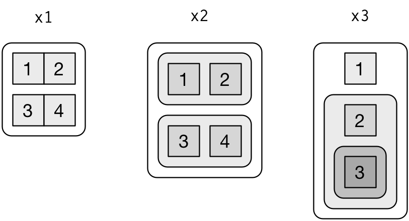

* **リストの構造を図示したもの**

### 1.5.2 Subsetting（サブセットの作成）

ここで用いるリストの例：

```r
a <- list(a = 1:3, b = "a string", c = pi, d = list(-1, -5))
```

- `a[]`による抽出（戻り値はリスト）：

```r
str(a[1:2])
```

```
## List of 2
##  $ a: int [1:3] 1 2 3
##  $ b: chr "a string"
```

```r
str(a[4])
```

```
## List of 1
##  $ d:List of 2
##   ..$ : num -1
##   ..$ : num -5
```

- `a[[]]`による抽出（戻り値はリストの中の要素）：

```r
str(a[[1]])
```

```
##  int [1:3] 1 2 3
```

```r
str(a[[4]])
```

```
## List of 2
##  $ : num -1
##  $ : num -5
```

- `$`：要素に名前がついているときに使える：

```r
a$a
```

```
## [1] 1 2 3
```

```r
a[["a"]]
```

```
## [1] 1 2 3
```

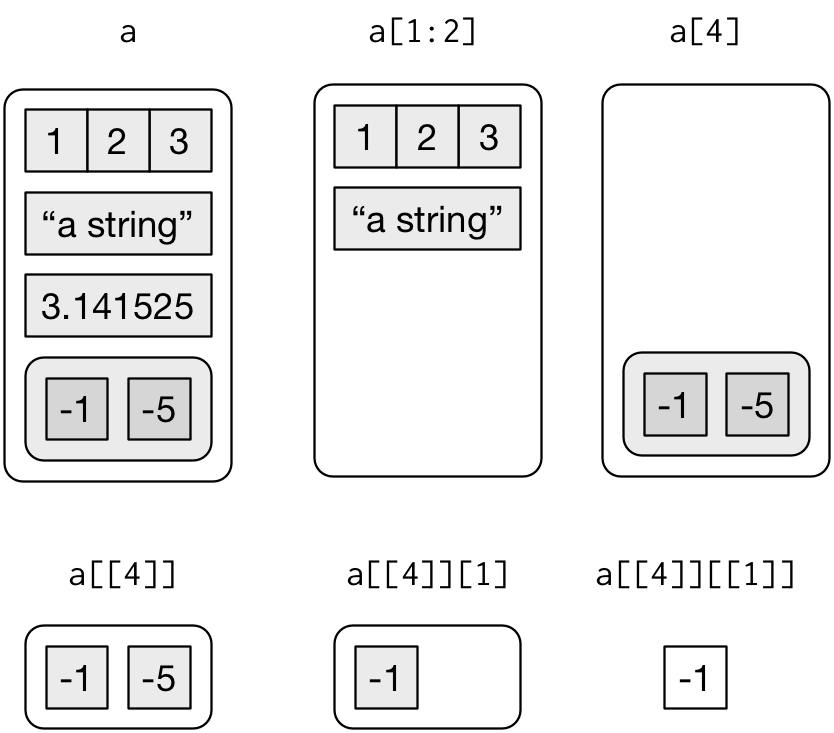

* **リストのサブセットを図示したもの**

### 1.5.3 Lists of condiments（香辛料のリスト）

- `[`と`[[`の違い：とても重要だが混同しやすい．

**変わった胡椒入れ（リストの例え）**

[figure not shown]

* **変わった胡椒入れ**

この胡椒入れがリスト`x`であるとすると・・・  
* `x[1]`：1つの胡椒袋が入った胡椒入れ．

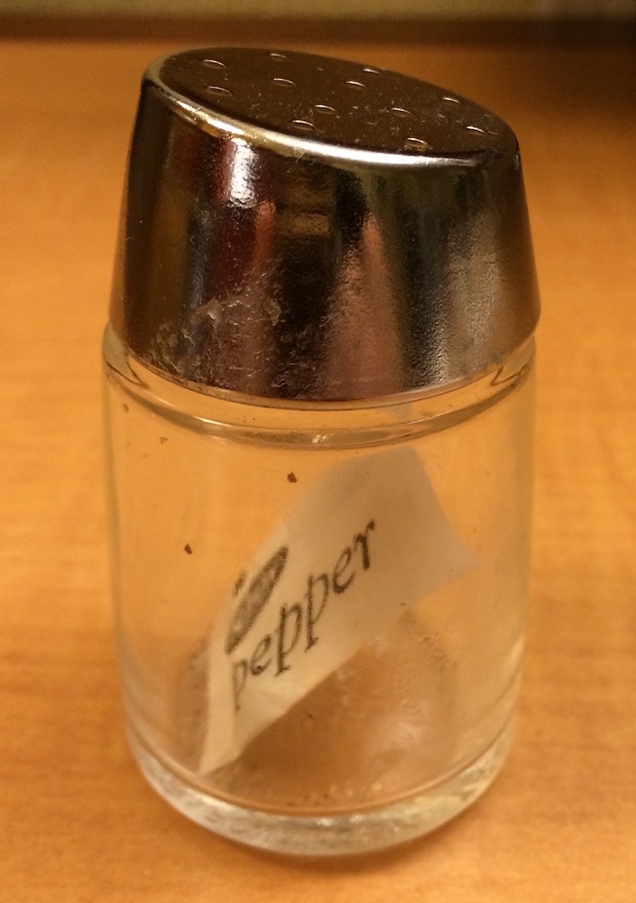

- `x[2]`：2つ目の胡椒袋が入った胡椒入れ．
- `x[1:2]`：2つの胡椒袋が入った胡椒入れ．
- `x[[1]]`は・・・：

[figure not shown]

- 胡椒袋の中身を見る場合はx[[1]][[1]]とする:

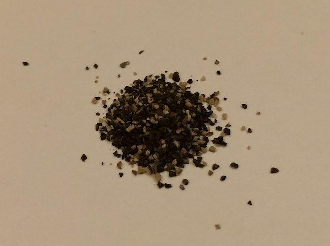

## 1.6 Attributes（属性）

ベクトルには任意の「属性（attribute）」を持たせることができる．  
これは，任意のオブジェクトに付属させられる名前のベクトルと考えることができる．

- `attr()`：オブジェクトに属性を持たせる，またはオブジェクトの属性を確認する．

```r
x <- 1:10
attr(x, "greeting")
```

```r
attr(x, "greeting") <- "Hi!" # "greeting"という属性を持たせる．
attr(x, "farewell") <- "Bye!" # "farewell"という属性を持たせる．
attributes(x) # xの属性の一覧を表示
```

```
## $greeting
## [1] "Hi!"
##
## $farewell
## [1] "Bye!"
```

**3つの重要な属性**

- Names（名前）：ベクトルの要素につく名前．
- Dimensions（次元）：ベクトルを行列や配列のように取り扱うことができる．
- Class（クラス）：S3オブジェクト指向システムの導入に用いられる．

クラスはRにおいてジェネリック関数の動きをコントロールする．ジェネリック関数はRにおけるオブジェクト指向プログラミングの鍵になる．入力のクラスが異なれば関数の挙動も異なる．より詳細には http://adv-r.had.co.nz/OO-essentials.html#s3 に記載がある．

- 典型的なジェネリック関数の例：

```r
as.Date
```

```
## function (x, ...)
## UseMethod("as.Date")
## <bytecode: 0x000000000b2baeb0>
## <environment: namespace:base>
```

- “UseMethod”：これがジェネリック関数であり，第一引数のクラスに応じてある特定のメソッド（関数）を呼び出すことを意味する（すべてのメソッドは関数であるが，すべての関数がメソッドというわけではない）．
- methods():ジェネリック関数のメソッドをリストアップする．

```r
methods("as.Date")
```

```
## [1] as.Date.character as.Date.date      as.Date.dates     as.Date.default
## [5] as.Date.factor    as.Date.numeric   as.Date.POSIXct   as.Date.POSIXlt
## see '?methods' for accessing help and source code
```

例：`x`が・・・

- 文字列ベクトルのとき：`as.Date()`は`as.Date.character()`を呼び出す．
- ファクターベクトルのとき：`as.Date()`は`as.Date.factor()`を呼び出す．
- getS3method()：メソッドの中身を見ることができる．

```r
getS3method("as.Date", "default")
```

```
## function (x, ...)
## {
##     if (inherits(x, "Date"))
##         return(x)
##     if (is.logical(x) && all(is.na(x)))
##         return(structure(as.numeric(x), class = "Date"))
##     stop(gettextf("do not know how to convert '%s' to class %s",
##         deparse(substitute(x)), dQuote("Date")), domain = NA)
## }
## <bytecode: 0x000000000afc4968>
## <environment: namespace:base>
```

```r
getS3method("as.Date", "numeric")
```

```
## function (x, origin, ...)
## {
##     if (missing(origin))
##         stop("'origin' must be supplied")
##     as.Date(origin, ...) + x
## }
## <bytecode: 0x000000000afc28c8>
## <environment: namespace:base>
```

## 1.7 Augmented vectors（拡張ベクトル）

- 拡張ベクトル（augmented vector）：atomic vectorsやlistsを基に組み立てられたfactorsやdatesなどのベクトルのことを拡張ベクトル（augmented vector）と呼ぶ．これらは，クラスなどの付加的な属性を持つ．  
  これらは属性としてクラスを持つため，どのatomic vectorが基になっているかによって挙動が異なる．

ここでは，以下の4つのベクトルについて説明する．

- Factors
- Dates
- Date-times
- Tibbles

### 1.7.1 Factors

- Factors：カテゴリーデータを表すためのベクトル．  
  整数の上に構築される．  
  “levels”（レベル）の属性を持つ：

```r
x <- factor(c("ab", "cd", "ab"), levels = c("ab", "cd", "ef"))
typeof(x)
```

```
## [1] "integer"
```

```r
attributes(x)
```

```
## $levels
## [1] "ab" "cd" "ef"
##
## $class
## [1] "factor"
```

### 1.7.2 Dates and date-times

- Date：数値（numeric）ベクトル．  
  1970年1月1日からの日数で表す：

```r
x <- as.Date("1971-01-01")
unclass(x)
```

```
## [1] 365
```

```r
typeof(x)
```

```
## [1] "double"
```

```r
attributes(x)
```

```
## $class
## [1] "Date"
```

- Date-time：数値（numeric）ベクトル．  
  POSIXctクラス．  
  1970年1月1日からの秒数で表す．  
  （“POSIXct” = “Portable Operating System Interface”, calendar time.)

```r
x <- lubridate::ymd_hm("1970-01-01 01:00")
unclass(x)
```

```
## [1] 3600
## attr(,"tzone")
## [1] "UTC"
```

```r
typeof(x)
```

```
## [1] "double"
```

```r
attributes(x)
```

```
## $tzone
## [1] "UTC"
##
## $class
## [1] "POSIXct" "POSIXt"
```

- tzone属性（オプション）：時間がどのように印字されるかをコントロールする．

```r
attr(x, "tzone") <- "US/Pacific"
x
```

```
## [1] "1969-12-31 17:00:00 PST"
```

```r
attr(x, "tzone") <- "US/Eastern"
x
```

```
## [1] "1969-12-31 20:00:00 EST"
```

- POSIXlt：date-timesの別のクラス．named listsの上に構築される：

```r
y <- as.POSIXlt(x)
typeof(y)
```

```
## [1] "list"
```

```r
attributes(y)
```

```
## $names
##  [1] "sec"    "min"    "hour"   "mday"   "mon"    "year"   "wday"
##  [8] "yday"   "isdst"  "zone"   "gmtoff"
##
## $class
## [1] "POSIXlt" "POSIXt"
##
## $tzone
## [1] "US/Eastern" "EST"        "EDT"
```

### 1.7.3 Tibbles

Tibbles：拡張リストの一種．  
クラス属性としては“tbl_df” + “tbl” + “data.frame”,  
他の属性としてnames（column）及びrow.namesを持つ:

```r
tb <- tibble::tibble(x = 1:5, y = 5:1)
typeof(tb)
```

```
## [1] "list"
```

```r
attributes(tb)
```

```
## $names
## [1] "x" "y"
##
## $class
## [1] "tbl_df"     "tbl"        "data.frame"
##
## $row.names
## [1] 1 2 3 4 5
```

tibbleはlistとは異なり，データフレームのそれぞれの要素は長さの等しいベクトルである必要がある．  
伝統的なデータフレームはよく似た構造を持つ．

```r
df <- data.frame(x = 1:5, y = 5:1)
typeof(df)
```

```
## [1] "list"
```

```r
attributes(df)
```

```
## $names
## [1] "x" "y"
##
## $row.names
## [1] 1 2 3 4 5
##
## $class
## [1] "data.frame"
```

両者の主な違いはクラスである．tibbleにはdata.frameクラスが含まれる．よって，tibbleはdata.frameと同様の挙動も示す．